# Data Preparation Before Plotting

# Goal

This notebook shows a basic workflow for inspecting and preparing data before plotting.

We will save a few intermediate data frames so it is clear what changed at each step.

# Analytic Questions

We will use the NHANES file from the data repository to practice the following `dplyr` actions:

- inspect
- filter
- recode
- count
- summarize
- arrange

# Load Data

Keep the first object close to the file as read from disk.

```r
raw_data <- readr::read_csv("data/real/nhanes_2021_2023_analysis.csv")
```

# Inspect The Data

Start by looking at the structure and a few rows.

```r
glimpse(raw_data)
```

```
Rows: 11,933
Columns: 57
$ respondent_id                 <dbl> 130378, 130379, 130380, 130381, 130382, …
$ release_cycle                 <dbl> 12, 12, 12, 12, 12, 12, 12, 12, 12, 12, …
$ interview_exam_status         <chr> "interviewed_and_examined", "interviewed…
$ gender                        <chr> "male", "male", "female", "female", "mal…
$ age_years                     <dbl> 43, 66, 44, 5, 2, 3, 43, 65, 34, 68, 27,…
$ age_months_screening_0_to_24  <dbl> NA, NA, NA, NA, NA, NA, NA, NA, NA, NA, …
$ age_group                     <chr> "30-44", "65-79", "30-44", "0-17", "0-17…
$ race_ethnicity                <chr> "Non-Hispanic Asian", "Non-Hispanic Whit…
$ exam_period                   <chr> "May-October", "May-October", "November-…
$ born_in_us                    <chr> "no", "yes", "no", "yes", "yes", "yes", …
$ years_in_us_category          <chr> "20 years or more", NA, "20 years or mor…
$ education_adults_20_plus      <chr> "College graduate or above", "College gr…
$ marital_status_adults_20_plus <chr> "Married/living with partner", "Married/…
```

[output cut: 44 more lines]

Or you can use the pipe format (`|>` *pipes* the value and feeds it to the first argument of the next function in the pipe)

```r
raw_data |>
  glimpse()
```

```
Rows: 11,933
Columns: 57
$ respondent_id                 <dbl> 130378, 130379, 130380, 130381, 130382, …
$ release_cycle                 <dbl> 12, 12, 12, 12, 12, 12, 12, 12, 12, 12, …
$ interview_exam_status         <chr> "interviewed_and_examined", "interviewed…
$ gender                        <chr> "male", "male", "female", "female", "mal…
$ age_years                     <dbl> 43, 66, 44, 5, 2, 3, 43, 65, 34, 68, 27,…
$ age_months_screening_0_to_24  <dbl> NA, NA, NA, NA, NA, NA, NA, NA, NA, NA, …
$ age_group                     <chr> "30-44", "65-79", "30-44", "0-17", "0-17…
$ race_ethnicity                <chr> "Non-Hispanic Asian", "Non-Hispanic Whit…
$ exam_period                   <chr> "May-October", "May-October", "November-…
$ born_in_us                    <chr> "no", "yes", "no", "yes", "yes", "yes", …
$ years_in_us_category          <chr> "20 years or more", NA, "20 years or mor…
$ education_adults_20_plus      <chr> "College graduate or above", "College gr…
$ marital_status_adults_20_plus <chr> "Married/living with partner", "Married/…
```

[output cut: 44 more lines]

Head shows the first handful of rows, which is nice for giving readers of your notebook a sense of the data.

```r
head(raw_data)
```

```
# A tibble: 6 × 57
  respondent_id release_cycle interview_exam_status    gender age_years
          <dbl>         <dbl> <chr>                    <chr>      <dbl>
1        130378            12 interviewed_and_examined male          43
2        130379            12 interviewed_and_examined male          66
3        130380            12 interviewed_and_examined female        44
4        130381            12 interviewed_and_examined female         5
5        130382            12 interviewed_and_examined male           2
6        130383            12 interviewed_only         female         3
# ℹ 52 more variables: age_months_screening_0_to_24 <dbl>, age_group <chr>,
#   race_ethnicity <chr>, exam_period <chr>, born_in_us <chr>,
#   years_in_us_category <chr>, education_adults_20_plus <chr>,
#   marital_status_adults_20_plus <chr>, pregnancy_status_exam <chr>,
#   household_size <dbl>, family_income_to_poverty <dbl>,
#   interview_weight <dbl>, mec_exam_weight <dbl>,
#   masked_variance_stratum <dbl>, masked_variance_psu <dbl>, bp_arm <chr>, …
```

**Warning:** Be careful about using `glimpse()` and `head()` in notebooks with PHI that you will share.

See the names of columns in the data frame:

```r
names(raw_data)
```

```
 [1] "respondent_id"                 "release_cycle"
 [3] "interview_exam_status"         "gender"
 [5] "age_years"                     "age_months_screening_0_to_24"
 [7] "age_group"                     "race_ethnicity"
 [9] "exam_period"                   "born_in_us"
[11] "years_in_us_category"          "education_adults_20_plus"
[13] "marital_status_adults_20_plus" "pregnancy_status_exam"
[15] "household_size"                "family_income_to_poverty"
[17] "interview_weight"              "mec_exam_weight"
[19] "masked_variance_stratum"       "masked_variance_psu"
[21] "bp_arm"                        "cuff_size"
[23] "systolic_1"                    "diastolic_1"
[25] "systolic_2"                    "diastolic_2"
[27] "systolic_3"                    "diastolic_3"
[29] "pulse_1"                       "pulse_2"
[31] "pulse_3"                       "systolic_mean"
[33] "diastolic_mean"                "pulse_mean"
[35] "systolic_n_readings"           "diastolic_n_readings"
[37] "phlebotomy_weight"             "hepatitis_a_antibody"
[39] "hepatitis_a_antibody_positive" "dietary_days"
[41] "mean_daily_energy_kcal"        "mean_daily_total_sugars_g"
[43] "mean_daily_dietary_fiber_g"    "mean_daily_total_fat_g"
[45] "mean_daily_saturated_fat_g"    "mean_daily_sodium_mg"
[47] "mean_daily_potassium_mg"       "mean_daily_caffeine_mg"
[49] "mean_daily_alcohol_g"          "day1_energy_kcal"
[51] "day2_energy_kcal"              "day1_total_sugars_g"
[53] "day2_total_sugars_g"           "day1_sodium_mg"
[55] "day2_sodium_mg"                "adult_high_bp_range"
[57] "adult_bp_category_simplified"
```

Each row is one participant in the NHANES teaching file.

**Note:** NHANES is a complex survey. Do not treat these teaching examples as real national estimates.

# Select Variables

Use `select()` to keep the variables needed for the current question.

```r
bp_data <- raw_data |>
  select(
    respondent_id,
    age_years,
    age_group,
    gender,
    race_ethnicity,
    systolic_mean,
    diastolic_mean,
    pulse_mean
  )

bp_data |>
  head()
```

```
# A tibble: 6 × 8
  respondent_id age_years age_group gender race_ethnicity          systolic_mean
          <dbl>     <dbl> <chr>     <chr>  <chr>                           <dbl>
1        130378        43 30-44     male   Non-Hispanic Asian               133.
2        130379        66 65-79     male   Non-Hispanic White               117
3        130380        44 30-44     female Other Hispanic                   109
4        130381         5 0-17      female Other race including m…           NA
5        130382         2 0-17      male   Non-Hispanic White                NA
6        130383         3 0-17      female Other Hispanic                    NA
# ℹ 2 more variables: diastolic_mean <dbl>, pulse_mean <dbl>
```

# Filter Rows

Use `filter()` to keep the observations that match the question.

Here we keep adults with a non-missing systolic blood pressure value.

| Data preparation step | Functions in this chunk |
| --- | --- |
| Inspect data | `glimpse()` |
| Keep or remove rows | `filter()` |

```r
adult_bp <- bp_data |>
  filter(
    age_years >= 18,
    !is.na(systolic_mean)
  )

adult_bp |>
  glimpse()
```

```
Rows: 6,123
Columns: 8
$ respondent_id  <dbl> 130378, 130379, 130380, 130386, 130387, 130388, 130389,…
$ age_years      <dbl> 43, 66, 44, 34, 68, 27, 59, 31, 33, 74, 39, 51, 33, 56,…
$ age_group      <chr> "30-44", "65-79", "30-44", "30-44", "65-79", "18-29", "…
$ gender         <chr> "male", "male", "female", "male", "female", "female", "…
$ race_ethnicity <chr> "Non-Hispanic Asian", "Non-Hispanic White", "Other Hisp…
$ systolic_mean  <dbl> 132.66667, 117.00000, 109.00000, 115.00000, 141.33333, …
$ diastolic_mean <dbl> 96.00000, 78.66667, 78.33333, 73.66667, 76.00000, 99.66…
$ pulse_mean     <dbl> 81.00000, 72.00000, 81.33333, 62.33333, 79.00000, 82.00…
```

# Count Categories

Use `count()` to check categorical variables before plotting or grouping.

| Data preparation step | Functions in this chunk |
| --- | --- |
| Count or summarize | `count()` |

```r
adult_bp |>
  count(age_group, sort = TRUE)
```

```
# A tibble: 5 × 2
  age_group     n
  <chr>     <int>
1 45-64      2005
2 65-79      1618
3 30-44      1298
4 18-29       882
5 80+         320
```

This is basically the same as `table()`, except you get back a data frame with nicely named columns, which are easier to work with:

```r
table(adult_bp$age_group)
```

```
18-29 30-44 45-64 65-79   80+
  882  1298  2005  1618   320
```

Gender:

| Data preparation step | Functions in this chunk |
| --- | --- |
| Count or summarize | `count()` |

```r
adult_bp |>
  count(gender, sort = TRUE)
```

```
# A tibble: 2 × 2
  gender     n
  <chr>  <int>
1 female  3347
2 male    2776
```

# Create Or Recode Variables

Use `mutate()` for new variables or recoded categories.

| Data preparation step | Functions in this chunk |
| --- | --- |
| Choose or rename columns | `select()` |
| Create or change columns | `mutate()`; `case_when()` |

```r
clean_data <- adult_bp |>
  mutate(
    systolic_group = case_when(
      systolic_mean < 120 ~ "Less than 120",
      systolic_mean < 130 ~ "120 to 129",
      systolic_mean < 140 ~ "130 to 139",
      systolic_mean >= 140 ~ "140 or higher",
      TRUE ~ NA_character_
    ),
    pulse_group = case_when(
      is.na(pulse_mean) ~ "Missing pulse",
      pulse_mean < 60 ~ "Less than 60",
      pulse_mean < 80 ~ "60 to 79",
      pulse_mean < 100 ~ "80 to 99",
      pulse_mean >= 100 ~ "100 or higher"
    )
  )

clean_data |>
  select(respondent_id, age_years, gender, systolic_mean, systolic_group, pulse_mean, pulse_group) |>
  head()
```

```
# A tibble: 6 × 7
  respondent_id age_years gender systolic_mean systolic_group pulse_mean
          <dbl>     <dbl> <chr>          <dbl> <chr>               <dbl>
1        130378        43 male            133. 130 to 139           81
2        130379        66 male            117  Less than 120        72
3        130380        44 female          109  Less than 120        81.3
4        130386        34 male            115  Less than 120        62.3
5        130387        68 female          141. 140 or higher        79
6        130388        27 female          129  120 to 129           82
# ℹ 1 more variable: pulse_group <chr>
```

# Arrange Rows For Inspection

Use `arrange()` to inspect records at the high or low end of a variable.

| Data preparation step | Functions in this chunk |
| --- | --- |
| Choose or rename columns | `select()` |
| Sort rows | `arrange()`; `desc()` |

```r
clean_data |>
  arrange(desc(systolic_mean)) |>
  select(respondent_id, age_years, gender, systolic_mean, diastolic_mean, pulse_group) |>
  head()
```

```
# A tibble: 6 × 6
  respondent_id age_years gender systolic_mean diastolic_mean pulse_group
          <dbl>     <dbl> <chr>          <dbl>          <dbl> <chr>
1        132760        60 male            232.          118.  60 to 79
2        135571        65 male            215           118.  60 to 79
3        137481        58 male            211            74.3 Less than 60
4        134148        80 female          210.           94.7 Less than 60
5        140131        74 female          207.          106   80 to 99
6        131005        64 male            207.          115.  60 to 79
```

Sorting does not change the data. It helps us inspect the rows behind summaries and plots.

# Summarize The Whole Table

Use `summarize()` when you want one row of summary values.

| Data preparation step | Functions in this chunk |
| --- | --- |
| Count or summarize | `summarize()`; `n()` |

```r
clean_data |>
  summarize(
    participants = n(),
    high_systolic_count = sum(systolic_mean >= 130),
    mean_systolic = mean(systolic_mean),
    median_systolic = median(systolic_mean),
    min_systolic = min(systolic_mean),
    max_systolic = max(systolic_mean),
    iqr_systolic = IQR(systolic_mean),
    sd_systolic = sd(systolic_mean)
  )
```

```
# A tibble: 1 × 8
  participants high_systolic_count mean_systolic median_systolic min_systolic
         <int>               <int>         <dbl>           <dbl>        <dbl>
1         6123                1752          122.             120           70
# ℹ 3 more variables: max_systolic <dbl>, iqr_systolic <dbl>, sd_systolic <dbl>
```

# Summarize By Group

Use `group_by()` before `summarize()` when you want one summary row per group.

| Data preparation step | Functions in this chunk |
| --- | --- |
| Count or summarize | `group_by()`; `summarize()`; `n()` |
| Sort rows | `arrange()`; `desc()` |

```r
gender_summary <- clean_data |>
  group_by(gender) |>
  summarize(
    participants = n(),
    high_systolic_count = sum(systolic_mean >= 130),
    mean_systolic = mean(systolic_mean),
    median_systolic = median(systolic_mean),
    min_systolic = min(systolic_mean),
    max_systolic = max(systolic_mean),
    iqr_systolic = IQR(systolic_mean),
    sd_systolic = sd(systolic_mean),
    .groups = "drop"
  ) |>
  arrange(desc(mean_systolic))

gender_summary
```

```
# A tibble: 2 × 9
  gender participants high_systolic_count mean_systolic median_systolic
  <chr>         <int>               <int>         <dbl>           <dbl>
1 male           2776                 874          125.            123.
2 female         3347                 878          120.            117.
# ℹ 4 more variables: min_systolic <dbl>, max_systolic <dbl>,
#   iqr_systolic <dbl>, sd_systolic <dbl>
```

# Format A Table With `kable()`

Plain data frames print fine while we work, but rendered notebooks often look better with a formatted table.

`knitr::kable()` takes a data frame and prints it as a simple table in the rendered document.

```r
gender_summary |>
  knitr::kable(
    digits = 1,
    caption = "Systolic blood pressure summaries by gender"
  )
```

Systolic blood pressure summaries by gender

| gender | participants | high_systolic_count | mean_systolic | median_systolic | min_systolic | max_systolic | iqr_systolic | sd_systolic |
| --- | --- | --- | --- | --- | --- | --- | --- | --- |
| male | 2776 | 874 | 124.9 | 122.7 | 70 | 232.3 | 19.3 | 16.7 |
| female | 3347 | 878 | 120.4 | 116.7 | 76 | 210.3 | 23.3 | 18.8 |

This does not change `gender_summary`. It only changes how the table is displayed in the notebook output.

# Factors And Category Order

Categorical variables are often stored as character vectors or factors.

For plotting, the important issue is order: what comes first, second, third, and so on.

If we do nothing, `ggplot2` often uses alphabetical order for character categories. This is not always the order we want.

Blood pressure groups have a natural order from lower to higher. We should preserve that order instead of sorting alphabetically or by count.

| Data preparation step | Functions in this chunk |
| --- | --- |
| Create or change columns | `mutate()` |

```r
clean_data <- clean_data |>
  mutate(
    systolic_group = factor(
      systolic_group,
      levels = c(
        "Less than 120",
        "120 to 129",
        "130 to 139",
        "140 or higher"
      )
    )
  )
```

The `levels` argument gives the factor its order.

# Let `ggplot2` Count The Rows

For a simple count plot, `ggplot2` can count rows for us. This is the default behavior of `geom_bar()`.

| Plot component | Code in this chunk |
| --- | --- |
| Aesthetic mappings | `x` |
| Geoms / stats | `geom_bar()` |
| Scales / coordinates / facets / labels | `coord_flip()`; `labs()`; `theme_minimal()` |

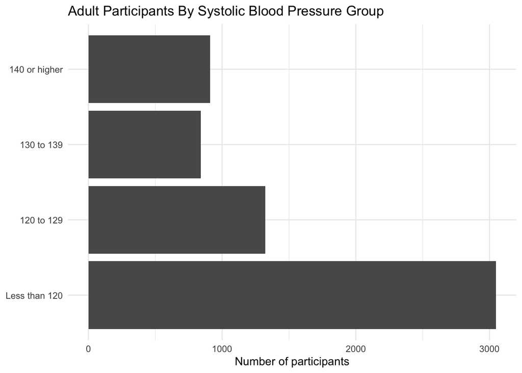

```r
ggplot(clean_data, aes(x = systolic_group)) +
  geom_bar() +
  coord_flip() +
  labs(
    title = "Adult Participants By Systolic Blood Pressure Group",
    x = NULL,
    y = "Number of participants"
  ) +
  theme_minimal()
```

This is convenient when the transformation is simple, but the count table is hidden inside the plot step.

# Transform First, Then Plot With Identity

Instead of asking `ggplot2` to count rows inside the plot, we can do the transformation ourselves and check the table before plotting.

| Data preparation step | Functions in this chunk |
| --- | --- |
| Count or summarize | `count()` |

```r
plot_data <- clean_data |>
  count(systolic_group)

plot_data
```

```
# A tibble: 4 × 2
  systolic_group     n
  <fct>          <int>
1 Less than 120   3048
2 120 to 129      1323
3 130 to 139       841
4 140 or higher    911
```

Now `stat = "identity"` tells `geom_bar()` to use the `n` values already in `plot_data`. As you get more comfortable, you may use this explicit pattern more often.

| Plot component | Code in this chunk |
| --- | --- |
| Aesthetic mappings | `x`; `y` |

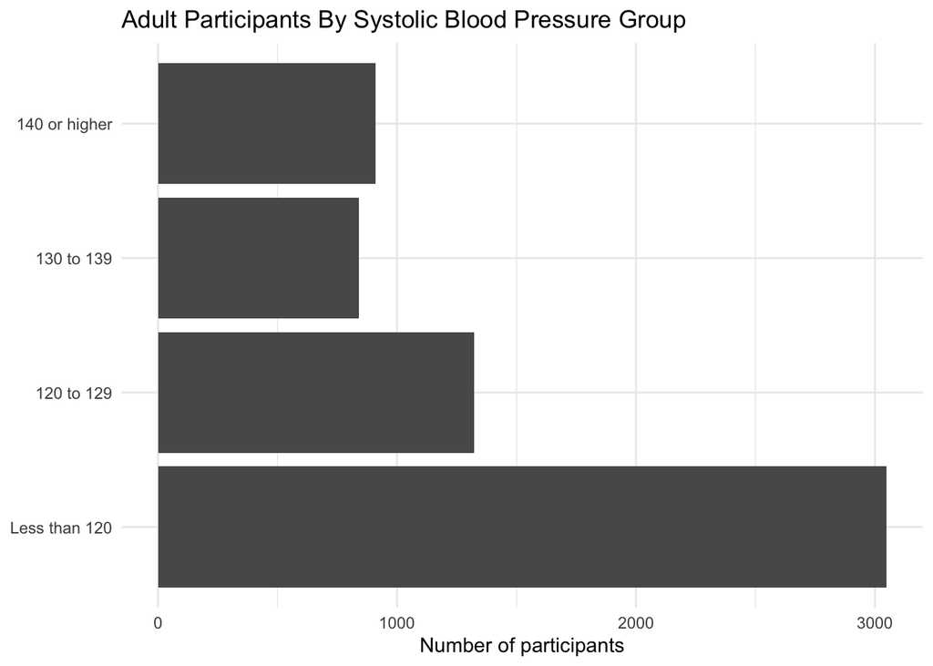

```r
ggplot(plot_data, aes(x = systolic_group, y = n)) +
  geom_bar(stat = "identity") +
  coord_flip() +
  labs(
    title = "Adult Participants By Systolic Blood Pressure Group",
    x = NULL,
    y = "Number of participants"
  ) +
  theme_minimal()
```

# Data Frame Naming

The named data frames in this notebook have specific jobs:

- `raw_data`: the file as read from disk
- `bp_data`: only the variables needed for the blood pressure question
- `adult_bp`: rows filtered to adults with systolic blood pressure data
- `clean_data`: recoded variables added
- `plot_data`: a small table made for one plot

This is enough. Avoid making a new object after every line if the object does not represent a useful stage.

# Summary

- Inspect data before visualizing.
- Keep the raw file import separate from cleaned or filtered data.
- Use `select()`, `filter()`, `mutate()`, `arrange()`, `count()`, `group_by()`, and `summarize()` to prepare data in small steps.
- Use summary functions such as `n()`, `sum()`, `mean()`, `median()`, `min()`, `max()`, `IQR()`, and `sd()` to check the data before plotting.
- Make a small plot-specific table when it clarifies what the plot is showing.